# Predict Bike Sharing Demand with AutoGluon Template

## Project: Predict Bike Sharing Demand with AutoGluon

This notebook is a template with each step that you need to complete for the project.

Please fill in your code where there are explicit `?` markers in the notebook. You are welcome to add more cells and code as you see fit.

Once you have completed all the code implementations, please export your notebook as a HTML file so the reviews can view your code. Make sure you have all outputs correctly outputted.

`File-> Export Notebook As... -> Export Notebook as HTML`

There is a writeup to complete as well after all code implememtation is done. Please answer all questions and attach the necessary tables and charts. You can complete the writeup in either markdown or PDF.

Completing the code template and writeup template will cover all of the rubric points for this project.

The rubric contains "Stand Out Suggestions" for enhancing the project beyond the minimum requirements. The stand out suggestions are optional. If you decide to pursue the "stand out suggestions", you can include the code in this notebook and also discuss the results in the writeup file.

## Step 1: Create an account with Kaggle

### Create Kaggle Account and download API key

Below is example of steps to get the API username and key. Each student will have their own username and key.

1. Open account settings.

2. Scroll down to API and click Create New API Token.

3. Open up `kaggle.json` and use the username and key.


## Step 2: Download the Kaggle dataset using the kaggle python library

### Open up Sagemaker Studio and use starter template

1. Notebook should be using a `ml.t3.medium` instance (2 vCPU + 4 GiB)
2. Notebook should be using kernal: `Python 3 (MXNet 1.8 Python 3.7 CPU Optimized)`

### Install packages

```python
!pip install -U pip
!pip install -U setuptools wheel
!pip install -U "mxnet<2.0.0" bokeh==2.0.1
!pip install autogluon --no-cache-dir
!pip install kaggle
# Without --no-cache-dir, smaller aws instances may have trouble installing
```

[output not shown]

[output cut: 254 more lines]

[output not shown]

### Setup Kaggle API Key

```python
# create the .kaggle directory and an empty kaggle.json file
!mkdir -p /root/.kaggle
!touch /root/.kaggle/kaggle.json
!chmod 600 /root/.kaggle/kaggle.json
```

### Go to the bike sharing demand competition and agree to the terms

```python
# Fill in your user name and key from creating the kaggle account and API token file
import json
kaggle_username = "lyndalebdjiri"
kaggle_key = "d45fbff843deb8806a24e303f975a0af"

# Save API token the kaggle.json file
with open("/root/.kaggle/kaggle.json", "w") as f:
    f.write(json.dumps({"username": kaggle_username, "key": kaggle_key}))
```

### Download and explore dataset

```python
# Download the dataset, it will be in a .zip file so you'll need to unzip it as well.
!kaggle competitions download -c bike-sharing-demand
# If you already downloaded it you can use the -o command to overwrite the file
!unzip -o bike-sharing-demand.zip
```

```
bike-sharing-demand.zip: Skipping, found more recently modified local copy (use --force to force download)
Archive:  bike-sharing-demand.zip
  inflating: sampleSubmission.csv
  inflating: test.csv
  inflating: train.csv
```

# Importing libraries

```python
import pandas as pd
import seaborn as sns
import autogluon.core as ag
import numpy as np
import matplotlib.pyplot as plt
from autogluon.tabular import TabularPredictor
from sklearn.preprocessing import  StandardScaler
```

# Loading Data

```python
#loading the train dataset
train = pd.read_csv("train.csv")
train.head()
```

|  | datetime | season | holiday | workingday | weather | temp | atemp | humidity | windspeed | casual | registered | count |
| --- | --- | --- | --- | --- | --- | --- | --- | --- | --- | --- | --- | --- |
| 0 | 2011-01-01 00:00:00 | 1 | 0 | 0 | 1 | 9.84 | 14.395 | 81 | 0.0 | 3 | 13 | 16 |
| 1 | 2011-01-01 01:00:00 | 1 | 0 | 0 | 1 | 9.02 | 13.635 | 80 | 0.0 | 8 | 32 | 40 |
| 2 | 2011-01-01 02:00:00 | 1 | 0 | 0 | 1 | 9.02 | 13.635 | 80 | 0.0 | 5 | 27 | 32 |
| 3 | 2011-01-01 03:00:00 | 1 | 0 | 0 | 1 | 9.84 | 14.395 | 75 | 0.0 | 3 | 10 | 13 |
| 4 | 2011-01-01 04:00:00 | 1 | 0 | 0 | 1 | 9.84 | 14.395 | 75 | 0.0 | 0 | 1 | 1 |

```python
#loading the test dataset
test = pd.read_csv("test.csv")
test.head()
```

|  | datetime | season | holiday | workingday | weather | temp | atemp | humidity | windspeed |
| --- | --- | --- | --- | --- | --- | --- | --- | --- | --- |
| 0 | 2011-01-20 00:00:00 | 1 | 0 | 1 | 1 | 10.66 | 11.365 | 56 | 26.0027 |
| 1 | 2011-01-20 01:00:00 | 1 | 0 | 1 | 1 | 10.66 | 13.635 | 56 | 0.0000 |
| 2 | 2011-01-20 02:00:00 | 1 | 0 | 1 | 1 | 10.66 | 13.635 | 56 | 0.0000 |
| 3 | 2011-01-20 03:00:00 | 1 | 0 | 1 | 1 | 10.66 | 12.880 | 56 | 11.0014 |
| 4 | 2011-01-20 04:00:00 | 1 | 0 | 1 | 1 | 10.66 | 12.880 | 56 | 11.0014 |

```python
#Loading the sampleSubmission.csv
submission = pd.read_csv("sampleSubmission.csv", parse_dates=["datetime"])
submission.head()
```

|  | datetime | count |
| --- | --- | --- |
| 0 | 2011-01-20 00:00:00 | 0 |
| 1 | 2011-01-20 01:00:00 | 0 |
| 2 | 2011-01-20 02:00:00 | 0 |
| 3 | 2011-01-20 03:00:00 | 0 |
| 4 | 2011-01-20 04:00:00 | 0 |

```python
# Converting the datetime column from the training dataset into  to datetime type
train['datetime'] = pd.to_datetime(train['datetime'])
```

```python
train['datetime'].dtypes
```

```
dtype('<M8[ns]')
```

```python
# Converting the datetime column from the testing dataset into  to datetime type
test["datetime"] = pd.to_datetime(test["datetime"])
```

```python
test['datetime'].dtypes
```

```
dtype('<M8[ns]')
```

```python
#overview of the training dataset
train.info()
```

```
<class 'pandas.core.frame.DataFrame'>
RangeIndex: 10886 entries, 0 to 10885
Data columns (total 12 columns):
 #   Column      Non-Null Count  Dtype
---  ------      --------------  -----
 0   datetime    10886 non-null  datetime64[ns]
 1   season      10886 non-null  int64
 2   holiday     10886 non-null  int64
 3   workingday  10886 non-null  int64
 4   weather     10886 non-null  int64
 5   temp        10886 non-null  float64
 6   atemp       10886 non-null  float64
 7   humidity    10886 non-null  int64
 8   windspeed   10886 non-null  float64
 9   casual      10886 non-null  int64
 10  registered  10886 non-null  int64
 11  count       10886 non-null  int64
dtypes: datetime64[ns](1), float64(3), int64(8)
memory usage: 1020.7 KB
```

```python
#overview of the testing dataset
test.info()
```

```
<class 'pandas.core.frame.DataFrame'>
RangeIndex: 6493 entries, 0 to 6492
Data columns (total 9 columns):
 #   Column      Non-Null Count  Dtype
---  ------      --------------  -----
 0   datetime    6493 non-null   datetime64[ns]
 1   season      6493 non-null   int64
 2   holiday     6493 non-null   int64
 3   workingday  6493 non-null   int64
 4   weather     6493 non-null   int64
 5   temp        6493 non-null   float64
 6   atemp       6493 non-null   float64
 7   humidity    6493 non-null   int64
 8   windspeed   6493 non-null   float64
dtypes: datetime64[ns](1), float64(3), int64(5)
memory usage: 456.7 KB
```

```python
#descriptive statistics about  the train dataset
train.describe()
```

|  | datetime | season | holiday | workingday | weather | temp | atemp | humidity | windspeed | casual | registered | count |
| --- | --- | --- | --- | --- | --- | --- | --- | --- | --- | --- | --- | --- |
| count | 10886 | 10886.000000 | 10886.000000 | 10886.000000 | 10886.000000 | 10886.00000 | 10886.000000 | 10886.000000 | 10886.000000 | 10886.000000 | 10886.000000 | 10886.000000 |
| mean | 2011-12-27 05:56:22.399411968 | 2.506614 | 0.028569 | 0.680875 | 1.418427 | 20.23086 | 23.655084 | 61.886460 | 12.799395 | 36.021955 | 155.552177 | 191.574132 |
| min | 2011-01-01 00:00:00 | 1.000000 | 0.000000 | 0.000000 | 1.000000 | 0.82000 | 0.760000 | 0.000000 | 0.000000 | 0.000000 | 0.000000 | 1.000000 |
| 25% | 2011-07-02 07:15:00 | 2.000000 | 0.000000 | 0.000000 | 1.000000 | 13.94000 | 16.665000 | 47.000000 | 7.001500 | 4.000000 | 36.000000 | 42.000000 |
| 50% | 2012-01-01 20:30:00 | 3.000000 | 0.000000 | 1.000000 | 1.000000 | 20.50000 | 24.240000 | 62.000000 | 12.998000 | 17.000000 | 118.000000 | 145.000000 |
| 75% | 2012-07-01 12:45:00 | 4.000000 | 0.000000 | 1.000000 | 2.000000 | 26.24000 | 31.060000 | 77.000000 | 16.997900 | 49.000000 | 222.000000 | 284.000000 |
| max | 2012-12-19 23:00:00 | 4.000000 | 1.000000 | 1.000000 | 4.000000 | 41.00000 | 45.455000 | 100.000000 | 56.996900 | 367.000000 | 886.000000 | 977.000000 |
| std | NaN | 1.116174 | 0.166599 | 0.466159 | 0.633839 | 7.79159 | 8.474601 | 19.245033 | 8.164537 | 49.960477 | 151.039033 | 181.144454 |

## Step 3: Train a model using AutoGluon’s Tabular Prediction

Requirements:

- We are prediting `count`, so it is the label we are setting.
- Ignore `casual` and `registered` columns as they are also not present in the test dataset.
- Use the `root_mean_squared_error` as the metric to use for evaluation.
- Set a time limit of 10 minutes (600 seconds).
- Use the preset `best_quality` to focus on creating the best model.

```python
predictor = TabularPredictor(label="count",
                             eval_metric="root_mean_squared_error",
                             learner_kwargs={"ignored_columns":["casual","registered"]}).fit(
train_data=train,
    time_limit=600,
    presets="best_quality")
```

[output not shown]

[output cut: 88 more lines]

```
	-53.4577	 = Validation score   (-root_mean_squared_error)
	32.7s	 = Training   runtime
	0.61s	 = Validation runtime
Fitting model: CatBoost_BAG_L2 ... Training model for up to 16.0s of the 15.94s of remaining time.
	Fitting 8 child models (S1F1 - S1F8) | Fitting with ParallelLocalFoldFittingStrategy (2 workers, per: cpus=1, gpus=0, memory=0.72%)
	-60.7448	 = Validation score   (-root_mean_squared_error)
	25.43s	 = Training   runtime
	0.05s	 = Validation runtime
Fitting model: WeightedEnsemble_L3 ... Training model for up to 360.0s of the -15.87s of remaining time.
	Ensemble Weights: {'RandomForestMSE_BAG_L2': 0.706, 'LightGBM_BAG_L2': 0.235, 'LightGBMXT_BAG_L2': 0.059}
	-53.1308	 = Validation score   (-root_mean_squared_error)
	0.03s	 = Training   runtime
	0.0s	 = Validation runtime
AutoGluon training complete, total runtime = 423.12s ... Best model: "WeightedEnsemble_L3"
TabularPredictor saved. To load, use: predictor = TabularPredictor.load("AutogluonModels/ag-20240430_195937")
```

### Review AutoGluon's training run with ranking of models that did the best.

```python
predictor.fit_summary()
```

```
*** Summary of fit() ***
Estimated performance of each model:
                     model   score_val              eval_metric  pred_time_val    fit_time  pred_time_val_marginal  fit_time_marginal  stack_level  can_infer  fit_order
0      WeightedEnsemble_L3  -53.130768  root_mean_squared_error      21.140177  353.437027                0.000612           0.033926            3       True         13
1   RandomForestMSE_BAG_L2  -53.457705  root_mean_squared_error      17.559374  280.011897                0.612283          32.702392            2       True         11
2          LightGBM_BAG_L2  -55.077617  root_mean_squared_error      17.181772  269.623545                0.234681          22.314040            2       True         10
3        LightGBMXT_BAG_L2  -60.209295  root_mean_squared_error      20.292600  298.386669                3.345509          51.077164            2       True          9
4          CatBoost_BAG_L2  -60.744817  root_mean_squared_error      16.999592  272.734788                0.052501          25.425283            2       True         12
5    KNeighborsDist_BAG_L1  -84.125061  root_mean_squared_error       0.058882    0.076441                0.058882           0.076441            1       True          2
6      WeightedEnsemble_L2  -84.125061  root_mean_squared_error       0.059778    0.115769                0.000896           0.039329            2       True          8
7    KNeighborsUnif_BAG_L1 -101.546199  root_mean_squared_error       0.057752    0.047822                0.057752           0.047822            1       True          1
8   RandomForestMSE_BAG_L1 -116.548359  root_mean_squared_error       0.560180   15.956176                0.560180          15.956176            1       True          5
9     ExtraTreesMSE_BAG_L1 -124.600676  root_mean_squared_error       0.928017    8.121107                0.928017           8.121107            1       True          7
10         CatBoost_BAG_L1 -130.875192  root_mean_squared_error       0.089257  114.226291                0.089257         114.226291            1       True          6
11         LightGBM_BAG_L1 -131.054162  root_mean_squared_error       1.675679   30.297253                1.675679          30.297253            1       True          4
12       LightGBMXT_BAG_L1 -131.460909  root_mean_squared_error      13.577325   78.584414               13.577325          78.584414            1       True          3
Number of models trained: 13
Types of models trained:
{'StackerEnsembleModel_LGB', 'StackerEnsembleModel_KNN', 'WeightedEnsembleModel', 'StackerEnsembleModel_XT', 'StackerEnsembleModel_CatBoost', 'StackerEnsembleModel_RF'}
Bagging used: True  (with 8 folds)
Multi-layer stack-ensembling used: True  (with 3 levels)
Feature Metadata (Processed):
(raw dtype, special dtypes):
('float', [])                : 3 | ['temp', 'atemp', 'windspeed']
('int', [])                  : 3 | ['season', 'weather', 'humidity']
('int', ['bool'])            : 2 | ['holiday', 'workingday']
('int', ['datetime_as_int']) : 5 | ['datetime', 'datetime.year', 'datetime.month', 'datetime.day', 'datetime.dayofweek']
*** End of fit() summary ***
```

[output not shown]

[output cut: 114 more lines]

```

     stack_level  can_infer  fit_order
 0             3       True         13
 1             2       True         11
 2             2       True         10
 3             2       True          9
 4             2       True         12
 5             1       True          2
 6             2       True          8
 7             1       True          1
 8             1       True          5
 9             1       True          7
 10            1       True          6
 11            1       True          4
 12            1       True          3  }
```

### Create predictions from test dataset

```python
predictions = predictor.predict(test)
predictions.head()
```

```
0    23.320108
1    42.760715
2    46.314487
3    49.534943
4    52.465004
Name: count, dtype: float32
```

#### NOTE: Kaggle will reject the submission if we don't set everything to be > 0.

```python
# Describe the `predictions` series to see if there are any negative values
predictions.describe()
```

```
count    6493.000000
mean      100.678345
std        90.179573
min         3.198889
25%        20.008636
50%        64.026909
75%       168.406677
max       367.750336
Name: count, dtype: float64
```

```python
# How many negative values do we have?
negative_values = predictions[predictions < 0 ]
sum(negative_values)
```

```
0
```

```python
# Set them to zero
predictions[predictions < 0] = 0
```

### Set predictions to submission dataframe, save, and submit

```python
submission["count"] = predictions
submission.to_csv("submission.csv", index=False)
```

```python
!kaggle competitions submit -c bike-sharing-demand -f submission.csv -m "first raw submission"
```

```
Successfully submitted to Bike Sharing Demand
```

#### View submission via the command line or in the web browser under the competition's page - `My Submissions`

```python
!kaggle competitions submissions -c bike-sharing-demand | tail -n +1 | head -n 6
```

```
fileName                     date                 description                        status    publicScore  privateScore
---------------------------  -------------------  ---------------------------------  --------  -----------  ------------
submission.csv               2024-04-30 20:11:00  first raw submission               complete  1.80433      1.80433
submission_new_features.csv  2024-04-29 23:47:21  new features                       complete  3.10406      3.10406
submission.csv               2024-04-29 23:35:00  first raw submission               complete  1.80363      1.80363
submission_new_features.csv  2024-04-29 19:36:29  new features                       complete  3.11435      3.11435
```

## Step 4: Exploratory Data Analysis and Creating an additional feature

- Any additional feature will do, but a great suggestion would be to separate out the datetime into hour, day, or month parts.

# **Data visualization**

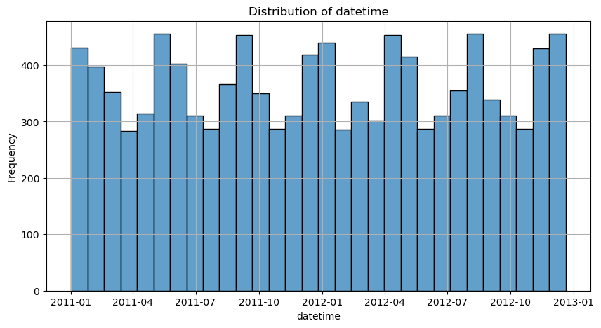

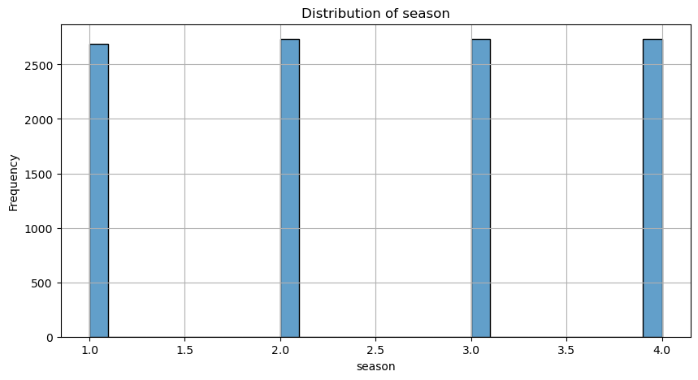

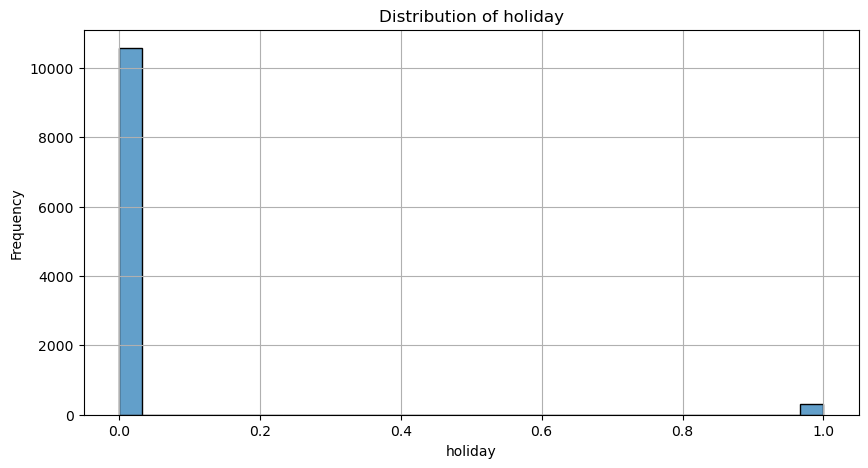

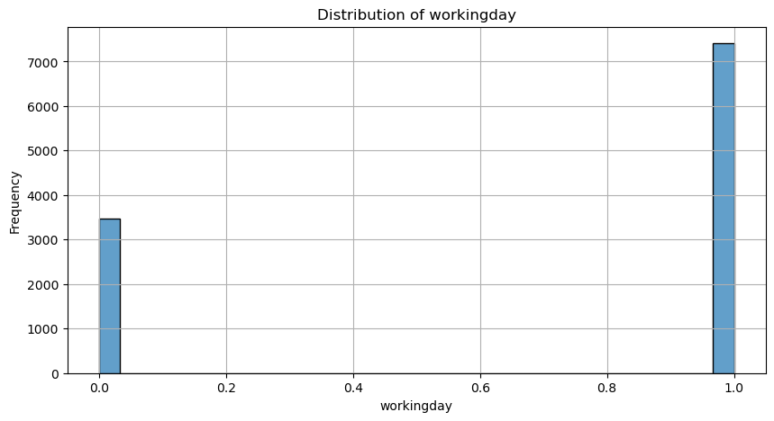

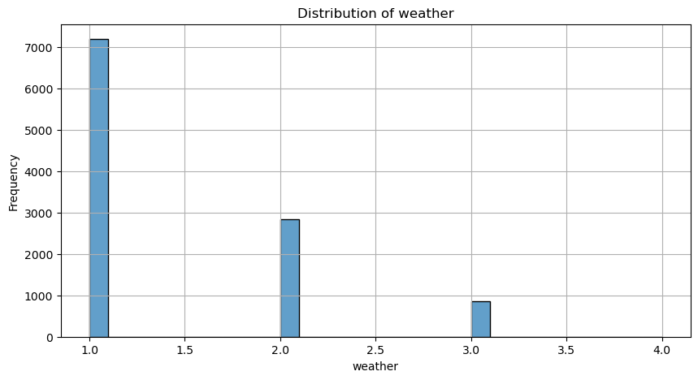

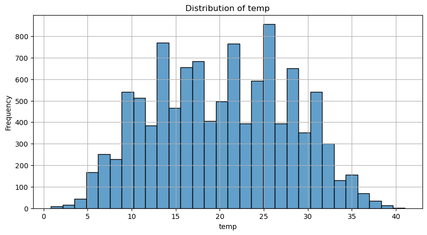

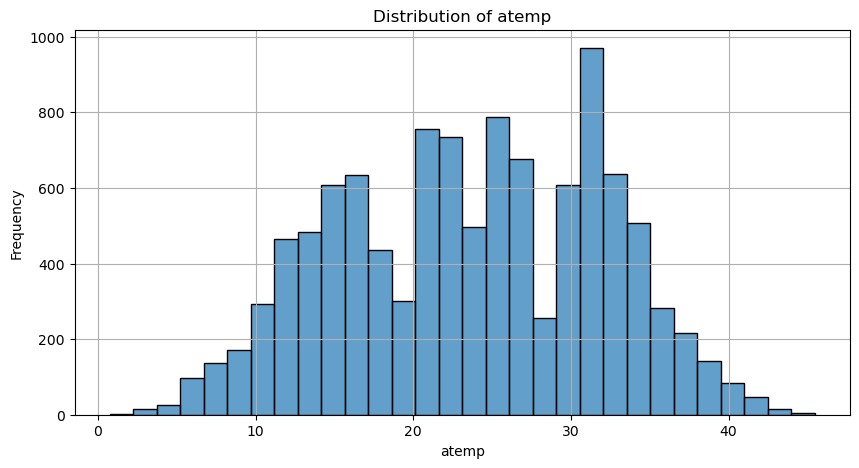

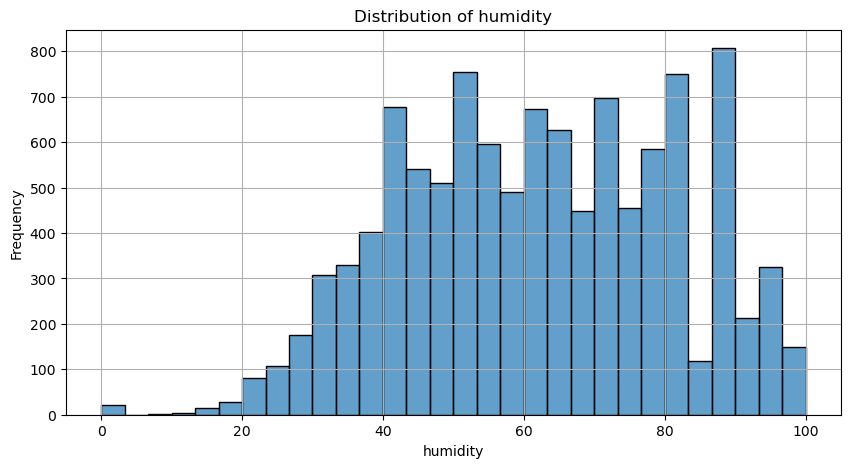

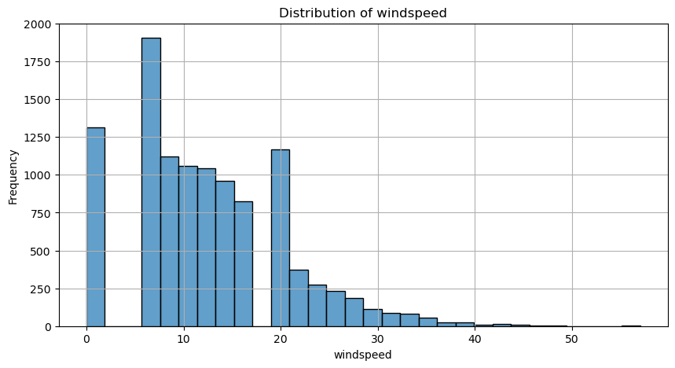

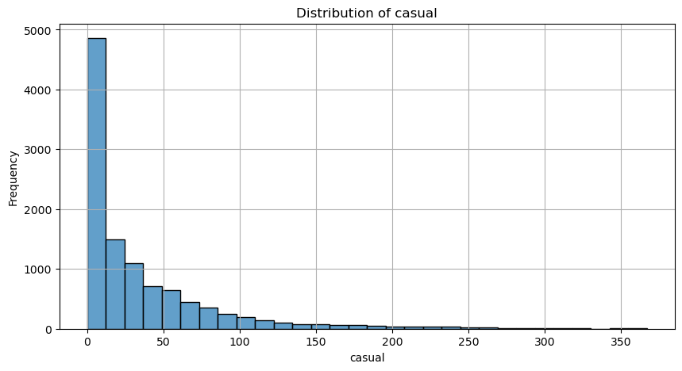

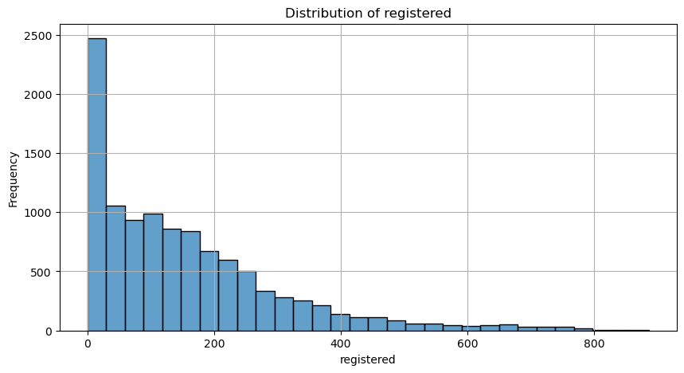

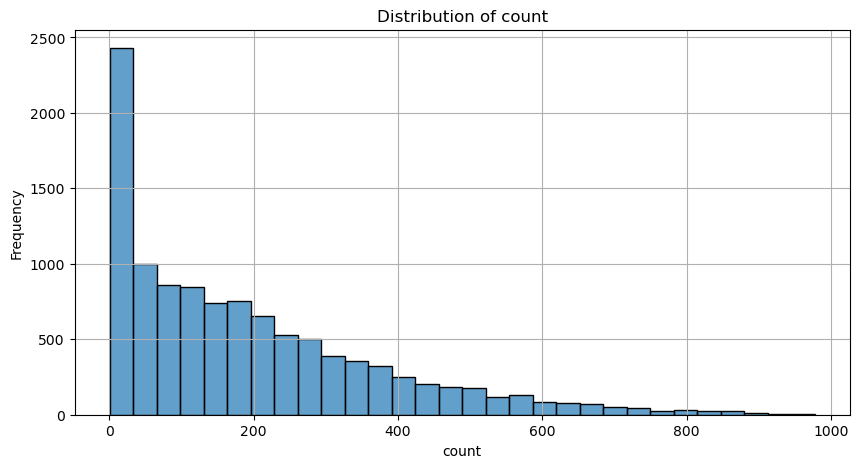

```python
# Creating a histogram for each feature from the train dataset
for feature in train.columns:
    plt.figure(figsize=(10, 5))
    sns.histplot(train[feature], bins=30, edgecolor='black', alpha=0.7)
    plt.title(f"Distribution of {feature}")
    plt.xlabel(feature)
    plt.ylabel("Frequency")
    plt.grid(True)
    plt.show()
```

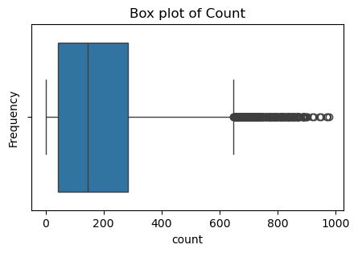

```python
# creating box plot for the feature count to check for outliers
plt.figure(figsize=(5, 3))
sns.boxplot(x=train['count'])
plt.title('Box plot of Count')
plt.ylabel('Frequency')
plt.show()
```

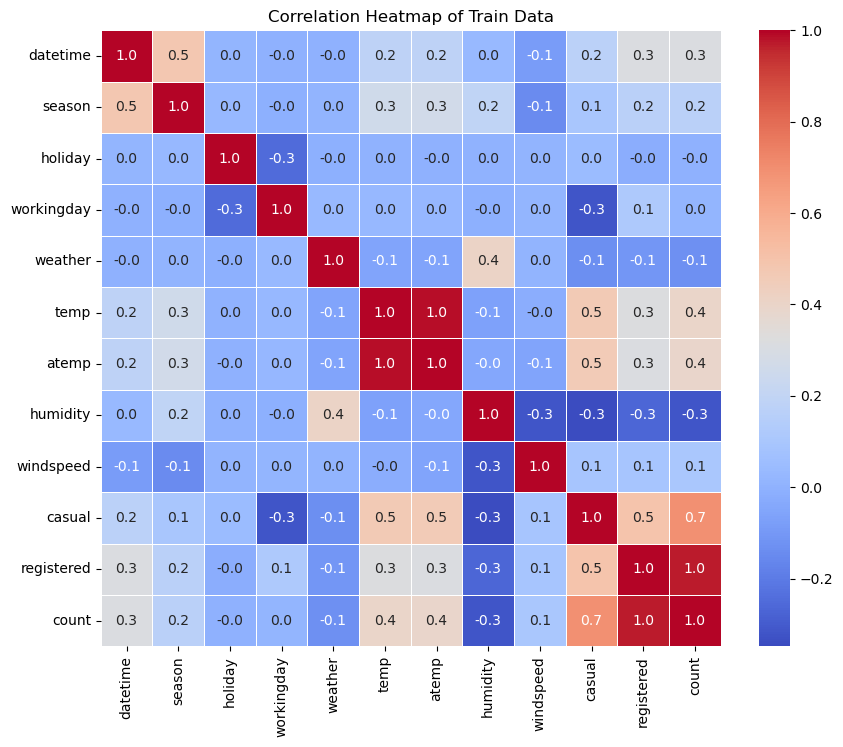

```python
#setting the size of the graph
plt.figure(figsize=(10, 8))

correlation_matrix = train.corr()

# Creating the heatmap using seaborn
sns.heatmap(correlation_matrix, cmap='coolwarm', annot=True, fmt=".1f", linewidths=.5)
#setting the title
plt.title('Correlation Heatmap of Train Data')  # Set a title for the heatmap


plt.show()
```

# **Data preprocessing**

```python
# Creating new features 'year', 'month', 'day', and 'hour' from the 'datetime' column in the 'train' dataset.
train["year"] = train.datetime.dt.year
train["month"] = train.datetime.dt.month
train["day"] = train.datetime.dt.day
train["hour"] = train.datetime.dt.hour
```

```python
# Creating new features 'year', 'month', 'day', and 'hour' from the 'datetime' column in the 'test' dataset.
test["year"] = test.datetime.dt.year
test["month"] = test.datetime.dt.month
test["day"] = test.datetime.dt.day
test["hour"] = test.datetime.dt.hour
```

```python
train.head()
```

|  | datetime | season | holiday | workingday | weather | temp | atemp | humidity | windspeed | casual | registered | count | year | month | day | hour |
| --- | --- | --- | --- | --- | --- | --- | --- | --- | --- | --- | --- | --- | --- | --- | --- | --- |
| 0 | 2011-01-01 00:00:00 | 1 | 0 | 0 | 1 | 9.84 | 14.395 | 81 | 0.0 | 3 | 13 | 16 | 2011 | 1 | 1 | 0 |
| 1 | 2011-01-01 01:00:00 | 1 | 0 | 0 | 1 | 9.02 | 13.635 | 80 | 0.0 | 8 | 32 | 40 | 2011 | 1 | 1 | 1 |
| 2 | 2011-01-01 02:00:00 | 1 | 0 | 0 | 1 | 9.02 | 13.635 | 80 | 0.0 | 5 | 27 | 32 | 2011 | 1 | 1 | 2 |
| 3 | 2011-01-01 03:00:00 | 1 | 0 | 0 | 1 | 9.84 | 14.395 | 75 | 0.0 | 3 | 10 | 13 | 2011 | 1 | 1 | 3 |
| 4 | 2011-01-01 04:00:00 | 1 | 0 | 0 | 1 | 9.84 | 14.395 | 75 | 0.0 | 0 | 1 | 1 | 2011 | 1 | 1 | 4 |

```python
test.head()
```

|  | datetime | season | holiday | workingday | weather | temp | atemp | humidity | windspeed | year | month | day | hour |
| --- | --- | --- | --- | --- | --- | --- | --- | --- | --- | --- | --- | --- | --- |
| 0 | 2011-01-20 00:00:00 | 1 | 0 | 1 | 1 | 10.66 | 11.365 | 56 | 26.0027 | 2011 | 1 | 20 | 0 |
| 1 | 2011-01-20 01:00:00 | 1 | 0 | 1 | 1 | 10.66 | 13.635 | 56 | 0.0000 | 2011 | 1 | 20 | 1 |
| 2 | 2011-01-20 02:00:00 | 1 | 0 | 1 | 1 | 10.66 | 13.635 | 56 | 0.0000 | 2011 | 1 | 20 | 2 |
| 3 | 2011-01-20 03:00:00 | 1 | 0 | 1 | 1 | 10.66 | 12.880 | 56 | 11.0014 | 2011 | 1 | 20 | 3 |
| 4 | 2011-01-20 04:00:00 | 1 | 0 | 1 | 1 | 10.66 | 12.880 | 56 | 11.0014 | 2011 | 1 | 20 | 4 |

# Create a mapping for 'season' and 'weather' based on the provided descriptions

- AutoGluon originally sees these as ints, but in reality they are int representations of a category.
- Setting the dtype to category will classify these as categories in AutoGluon.

```python
# Creating a mapping for 'season' and 'weather' based on the provided descriptions about the dataset in kaggle
season_mapping = {1: 'spring', 2: 'summer', 3: 'fall', 4: 'winter'}
weather_mapping = {
    1: 'Clear, Few clouds, Partly cloudy',
    2: 'Mist + Cloudy, Mist + Broken clouds, Mist + Few clouds, Mist',
    3: 'Light Snow, Light Rain + Thunderstorm + Scattered clouds, Light Rain + Scattered clouds',
    4: 'Heavy Rain + Ice Pallets + Thunderstorm + Mist, Snow + Fog'
}
```

```python
train['season'] = train['season'].replace(season_mapping)
train['weather'] = train['weather'].replace(weather_mapping)
```

```python
# Converting 'season' and 'weather' to category type
train['season'] = train['season'].astype('category')
train['weather'] = train['weather'].astype('category')
```

```python
# Creating a mapping for 'season' and 'weather' based on the provided descriptions about the dataset in kaggle
test['season'] = test['season'].replace(season_mapping)
test['weather'] = test['weather'].replace(weather_mapping)
```

```python
# Converting 'season' and 'weather' to category type
test['season'] = test['season'].astype('category')
test['weather'] = test['weather'].astype('category')
```

```python
train.head()
```

|  | datetime | season | holiday | workingday | weather | temp | atemp | humidity | windspeed | casual | registered | count | year | month | day | hour |
| --- | --- | --- | --- | --- | --- | --- | --- | --- | --- | --- | --- | --- | --- | --- | --- | --- |
| 0 | 2011-01-01 00:00:00 | spring | 0 | 0 | Clear, Few clouds, Partly cloudy | 9.84 | 14.395 | 81 | 0.0 | 3 | 13 | 16 | 2011 | 1 | 1 | 0 |
| 1 | 2011-01-01 01:00:00 | spring | 0 | 0 | Clear, Few clouds, Partly cloudy | 9.02 | 13.635 | 80 | 0.0 | 8 | 32 | 40 | 2011 | 1 | 1 | 1 |
| 2 | 2011-01-01 02:00:00 | spring | 0 | 0 | Clear, Few clouds, Partly cloudy | 9.02 | 13.635 | 80 | 0.0 | 5 | 27 | 32 | 2011 | 1 | 1 | 2 |
| 3 | 2011-01-01 03:00:00 | spring | 0 | 0 | Clear, Few clouds, Partly cloudy | 9.84 | 14.395 | 75 | 0.0 | 3 | 10 | 13 | 2011 | 1 | 1 | 3 |
| 4 | 2011-01-01 04:00:00 | spring | 0 | 0 | Clear, Few clouds, Partly cloudy | 9.84 | 14.395 | 75 | 0.0 | 0 | 1 | 1 | 2011 | 1 | 1 | 4 |

```python
test.head()
```

|  | datetime | season | holiday | workingday | weather | temp | atemp | humidity | windspeed | year | month | day | hour |
| --- | --- | --- | --- | --- | --- | --- | --- | --- | --- | --- | --- | --- | --- |
| 0 | 2011-01-20 00:00:00 | spring | 0 | 1 | Clear, Few clouds, Partly cloudy | 10.66 | 11.365 | 56 | 26.0027 | 2011 | 1 | 20 | 0 |
| 1 | 2011-01-20 01:00:00 | spring | 0 | 1 | Clear, Few clouds, Partly cloudy | 10.66 | 13.635 | 56 | 0.0000 | 2011 | 1 | 20 | 1 |
| 2 | 2011-01-20 02:00:00 | spring | 0 | 1 | Clear, Few clouds, Partly cloudy | 10.66 | 13.635 | 56 | 0.0000 | 2011 | 1 | 20 | 2 |
| 3 | 2011-01-20 03:00:00 | spring | 0 | 1 | Clear, Few clouds, Partly cloudy | 10.66 | 12.880 | 56 | 11.0014 | 2011 | 1 | 20 | 3 |
| 4 | 2011-01-20 04:00:00 | spring | 0 | 1 | Clear, Few clouds, Partly cloudy | 10.66 | 12.880 | 56 | 11.0014 | 2011 | 1 | 20 | 4 |

```python
#dropping casual and registered from the train Dataset
train.drop(["casual", "registered"], axis=1, inplace=True)
```

```python
train.head()
```

|  | datetime | season | holiday | workingday | weather | temp | atemp | humidity | windspeed | count | year | month | day | hour |
| --- | --- | --- | --- | --- | --- | --- | --- | --- | --- | --- | --- | --- | --- | --- |
| 0 | 2011-01-01 00:00:00 | spring | 0 | 0 | Clear, Few clouds, Partly cloudy | 9.84 | 14.395 | 81 | 0.0 | 16 | 2011 | 1 | 1 | 0 |
| 1 | 2011-01-01 01:00:00 | spring | 0 | 0 | Clear, Few clouds, Partly cloudy | 9.02 | 13.635 | 80 | 0.0 | 40 | 2011 | 1 | 1 | 1 |
| 2 | 2011-01-01 02:00:00 | spring | 0 | 0 | Clear, Few clouds, Partly cloudy | 9.02 | 13.635 | 80 | 0.0 | 32 | 2011 | 1 | 1 | 2 |
| 3 | 2011-01-01 03:00:00 | spring | 0 | 0 | Clear, Few clouds, Partly cloudy | 9.84 | 14.395 | 75 | 0.0 | 13 | 2011 | 1 | 1 | 3 |
| 4 | 2011-01-01 04:00:00 | spring | 0 | 0 | Clear, Few clouds, Partly cloudy | 9.84 | 14.395 | 75 | 0.0 | 1 | 2011 | 1 | 1 | 4 |

```python
# Applyying log transformation
train['count'] = train['count'].apply(lambda x: np.log(x) if x > 0 else 0)
```

```python
# using the IQR method
Q1 = train['count'].quantile(0.25)
Q3 = train['count'].quantile(0.75)
IQR = Q3 - Q1
```

```python
# Defining bounds for the IQR
lower_bound = Q1 - 1.5 * IQR
upper_bound = Q3 + 1.5 * IQR
```

```python
# Removing outliers
train = train[(train['count'] >= lower_bound) & (train['count'] <= upper_bound)]
```

```python
train["count"]
```

```
0        2.772589
1        3.688879
2        3.465736
3        2.564949
7        1.098612
           ...
10881    5.817111
10882    5.484797
10883    5.123964
10884    4.859812
10885    4.477337
Name: count, Length: 10649, dtype: float64
```

```python
train.head()
```

|  | datetime | season | holiday | workingday | weather | temp | atemp | humidity | windspeed | count | year | month | day | hour |
| --- | --- | --- | --- | --- | --- | --- | --- | --- | --- | --- | --- | --- | --- | --- |
| 0 | 2011-01-01 00:00:00 | spring | 0 | 0 | Clear, Few clouds, Partly cloudy | 9.84 | 14.395 | 81 | 0.0 | 2.772589 | 2011 | 1 | 1 | 0 |
| 1 | 2011-01-01 01:00:00 | spring | 0 | 0 | Clear, Few clouds, Partly cloudy | 9.02 | 13.635 | 80 | 0.0 | 3.688879 | 2011 | 1 | 1 | 1 |
| 2 | 2011-01-01 02:00:00 | spring | 0 | 0 | Clear, Few clouds, Partly cloudy | 9.02 | 13.635 | 80 | 0.0 | 3.465736 | 2011 | 1 | 1 | 2 |
| 3 | 2011-01-01 03:00:00 | spring | 0 | 0 | Clear, Few clouds, Partly cloudy | 9.84 | 14.395 | 75 | 0.0 | 2.564949 | 2011 | 1 | 1 | 3 |
| 7 | 2011-01-01 07:00:00 | spring | 0 | 0 | Clear, Few clouds, Partly cloudy | 8.20 | 12.880 | 86 | 0.0 | 1.098612 | 2011 | 1 | 1 | 7 |

```python
test.head()
```

|  | datetime | season | holiday | workingday | weather | temp | atemp | humidity | windspeed | year | month | day | hour |
| --- | --- | --- | --- | --- | --- | --- | --- | --- | --- | --- | --- | --- | --- |
| 0 | 2011-01-20 00:00:00 | spring | 0 | 1 | Clear, Few clouds, Partly cloudy | 10.66 | 11.365 | 56 | 26.0027 | 2011 | 1 | 20 | 0 |
| 1 | 2011-01-20 01:00:00 | spring | 0 | 1 | Clear, Few clouds, Partly cloudy | 10.66 | 13.635 | 56 | 0.0000 | 2011 | 1 | 20 | 1 |
| 2 | 2011-01-20 02:00:00 | spring | 0 | 1 | Clear, Few clouds, Partly cloudy | 10.66 | 13.635 | 56 | 0.0000 | 2011 | 1 | 20 | 2 |
| 3 | 2011-01-20 03:00:00 | spring | 0 | 1 | Clear, Few clouds, Partly cloudy | 10.66 | 12.880 | 56 | 11.0014 | 2011 | 1 | 20 | 3 |
| 4 | 2011-01-20 04:00:00 | spring | 0 | 1 | Clear, Few clouds, Partly cloudy | 10.66 | 12.880 | 56 | 11.0014 | 2011 | 1 | 20 | 4 |

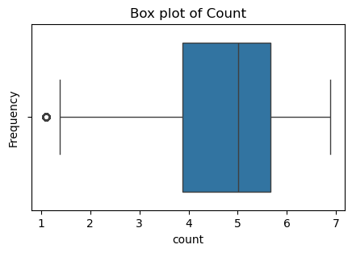

```python
# creating box plot for the feature count to check for outliers
plt.figure(figsize=(5, 3))
sns.boxplot(x=train['count'])
plt.title('Box plot of Count')
plt.ylabel('Frequency')
plt.show()
```

```python
#checking if we have null values in the train dataset
train.isnull().sum()
```

```
datetime      0
season        0
holiday       0
workingday    0
weather       0
temp          0
atemp         0
humidity      0
windspeed     0
count         0
year          0
month         0
day           0
hour          0
dtype: int64
```

```python
#checking if we have null values in the train dataset
train.isnull().sum()
```

```
datetime      0
season        0
holiday       0
workingday    0
weather       0
temp          0
atemp         0
humidity      0
windspeed     0
count         0
year          0
month         0
day           0
hour          0
dtype: int64
```

```python
# Checking for duplicated values in the train dataset
train.duplicated().sum()
```

```
0
```

```python
# Checking for duplicated values in the test dataset
test.duplicated().sum()
```

```
0
```